# RLab 05 – Simple Linear Regression Model

Roshan Thapa Magar

# Introduction

Let’s start with a question based on reading assignment for this module:

### Question 0

This question comes from exercises in section 23.2.1: One challenge with performing numerical optimization is that it’s only guaranteed to find one local optimum. What’s the problem with optimizing a three parameter model like this?

model1 <- function(a, data) { a[1] + data$x * a[2] + a[3] }

Hint: compare the formula in the code above with the simple linear regression formula.

##### Answer to Question 0

This model has too many parameters. Linear regression only needs two (intercept and slope), but this has three. Both a[1] and a[3] are constant terms, creating redundancy. The computer can’t find the best values because there are infinitely many combinations that work.

We’ll be using the `Salaries` data set that’s part of the `carData` package, so the first thing to do will be to load the `carData` package using the `library` command. We’ll also need tidyverse. The `head` command will remind you of the data set.

```r
library(carData)
library(tidyverse)
head(Salaries)
```

```
##        rank discipline yrs.since.phd yrs.service  sex salary
## 1      Prof          B            19          18 Male 139750
## 2      Prof          B            20          16 Male 173200
## 3  AsstProf          B             4           3 Male  79750
## 4      Prof          B            45          39 Male 115000
## 5      Prof          B            40          41 Male 141500
## 6 AssocProf          B             6           6 Male  97000
```

# Scatterplots to Explore Data Sets

## Scatterplots with the `pairs` Command

Suppose you’ve never seen a particular data set before, and you’d like to quickly get a sense for which variables are related. The `pairs` command helps you do that by creating a *grid* of scatter plots where each variable in a data frame is plotted against each other variable. The `pairs` command is part of base R and not part of `ggplot`. It’s syntax is simple:

`pairs(your data frame)`

Let’s look at the `Salaries` data frame:

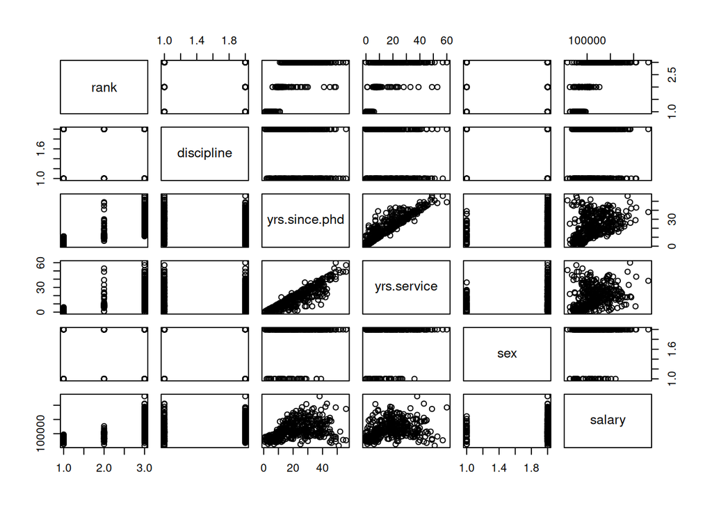

```r
pairs(Salaries)
```

Tracing vertically and horizontally from a particular graph to the variable names on the diagonal tells you which variables are on the vertical and horizontal axes of the graphs themselves. You can see some graphs are more useful than others, depending on what kind of variables you started with.

If there are variables you know you don’t want to graph, you could use the tidyverse `select` command to create a new data frame with only those variables before you use `pairs`.

### Question 1

1. In a sentence, describe the relationship between `yrs.service` and `yrs.since.phd`.
2. Why do you think there is a sharp edge on one side of the scatter plot of `yrs..service` and `yrs.since.phd`?
3. Which variable seems to have a stronger relationship (graphically) to `salary`–`yrs..service` or `yrs.since.phd`? Explain in a sentence.
4. Which graph appears to be least helpful? What variables are being graphed in that graph, and what kind of variables are they?

**Type Answers Below**

1. Strong positive relationship between years of service and years since PhD. More years since PhD means more years of service since people start working after their degree.
2. Sharp edge exists because you can’t have more years of service than years since PhD. All points stay on or below the diagonal line.
3. Years since PhD has stronger connection to salary than years of service. The salary vs years since PhD plot shows a clearer straight line pattern.
4. Least helpful graph shows categorical variables like rank vs discipline. These are just categories, so plotting them against each other doesn’t show relationships.

## Scatterplots with `ggplot`

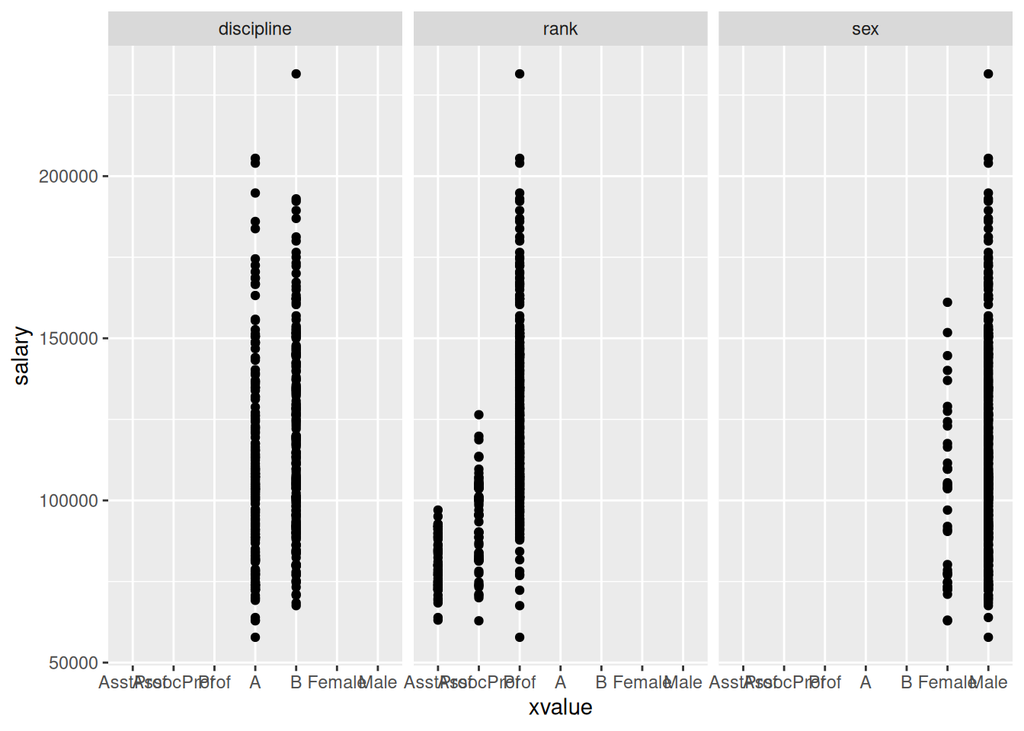

```r
Salaries %>%
  pivot_longer(c(rank, discipline, sex),names_to="xvar", values_to="xvalue") %>%
  ggplot() +
  geom_point(mapping=aes(x=xvalue, y=salary)) +
  facet_wrap(facets="xvar")
```

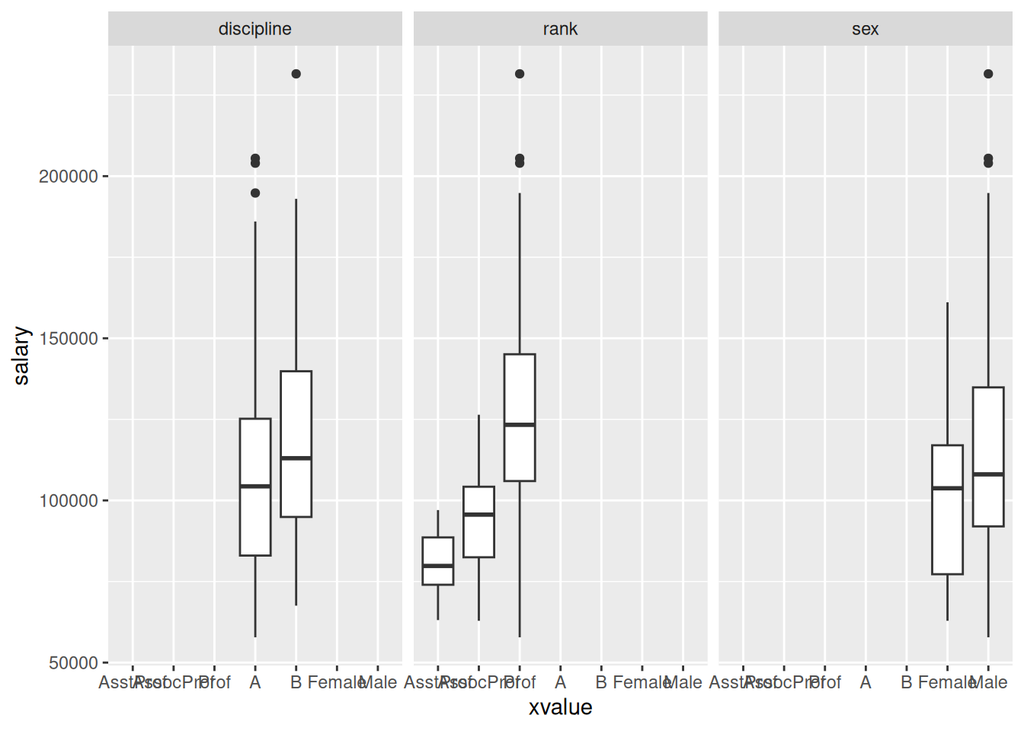

```r
Salaries %>%
  pivot_longer(c(rank, discipline, sex),names_to="xvar", values_to="xvalue") %>%
  ggplot() +
  geom_boxplot(mapping=aes(x=xvalue, y=salary)) +
  facet_wrap(facets="xvar")
```

This last one doesn’t work so well with factor variables, since each graph includes *all* factor variables on each graph, but we can still get the idea. It might be better, however, to make individual graphs.

Let’s focus just on `yrs.since.phd` and `salary` right now. We can use `stat_smooth` to add a line of best fit. The last option, `method="lm"`, ensures that we get a line and not a curve.

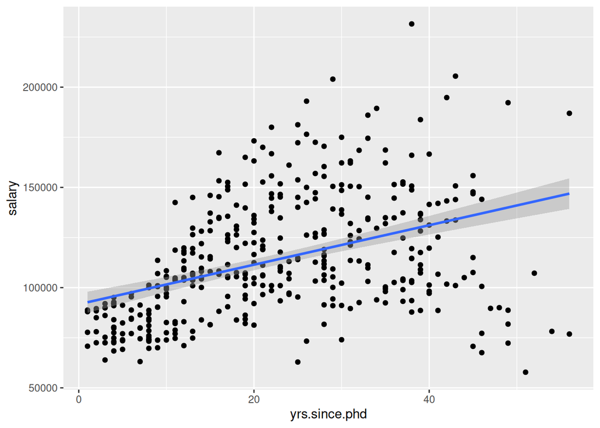

```r
Salaries %>%
  ggplot() +
  geom_point(mapping=aes(x=yrs.since.phd, y=salary)) +
  stat_smooth(mapping=aes(x=yrs.since.phd, y=salary), method="lm")
```

It seems that salary is related to yrs.since.phd (and to yrs.service). Is that relationship different for male and female faculty members? We can add a `color` element to the mapping in `geom_point` and `stat_smooth` to find out:

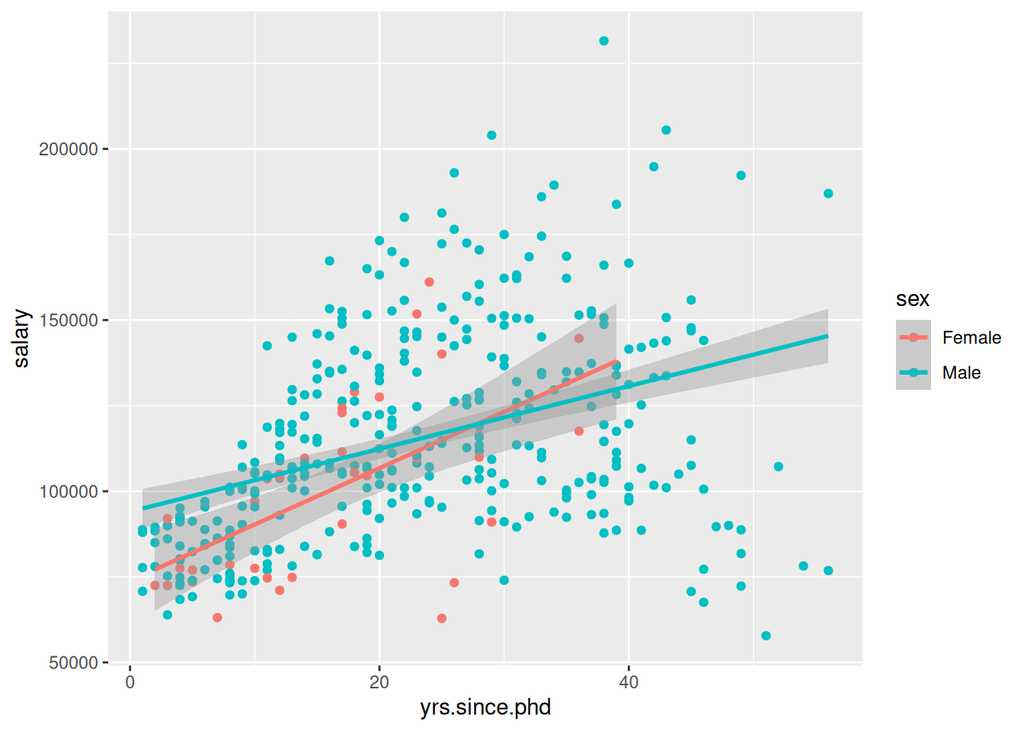

```r
Salaries %>%
  ggplot() +
  geom_point(mapping=aes(x=yrs.since.phd, y=salary, color=sex)) +
  stat_smooth(mapping=aes(x=yrs.since.phd, y=salary, color=sex), method="lm")
```

### Question 2

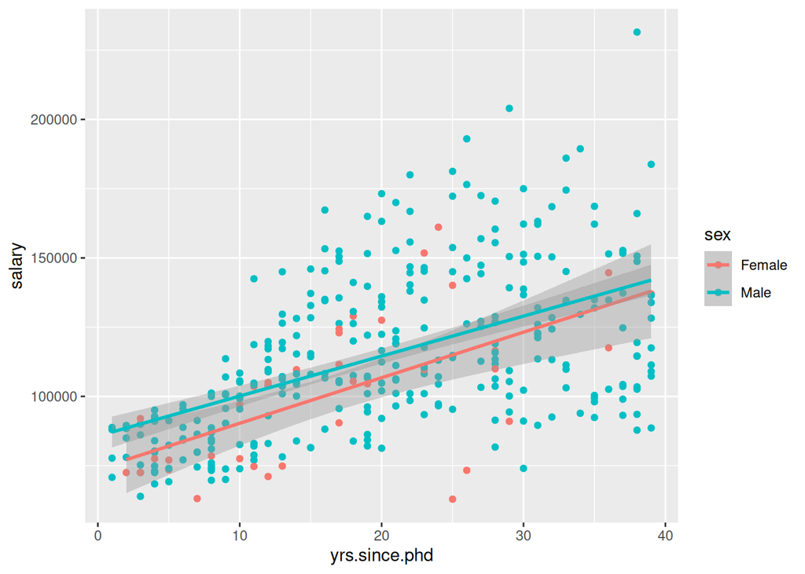

```r
# Filter data to only include faculty with less than 40 years since PhD
Salaries %>%
  filter(yrs.since.phd < 40) %>%
  ggplot() +
  geom_point(mapping=aes(x=yrs.since.phd, y=salary, color=sex)) +
  stat_smooth(mapping=aes(x=yrs.since.phd, y=salary, color=sex), method="lm")
```

# The Linear Correlation Coefficient

You should remember from Basic Statistics that the *linear correlation coefficient* (denoted by *r*) is a statistic that ranges from -1 to 1 and gives information on how two numeric variables are linearly related. Pictures speak louder than words:

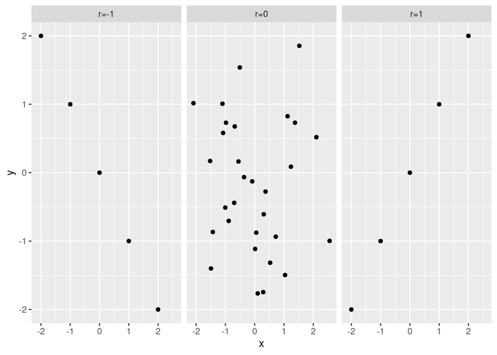

```r
# You don't have to pay too much attention to this code--it just creates the
# pictures you should look at (in the knit document).
df = data.frame(x=c(-2:2, rnorm(30), -2:2), y=c(2:(-2), rnorm(30), -2:2),
  r = c(rep("r=-1", 5), rep("r=0", 30), rep("r=1", 5)))
ggplot(data=df) +
  geom_point(mapping=aes(x=x, y=y)) +
  facet_wrap(facets="r")
```

The `cor` function measures the linear correlation between two numeric variables. It has the form `cor(var1, var2)`

Here are two ways to use the `cor` command to calculate the linear correlation between `salary` and `yrs.since.phd`. Note that the output is a bit different, depending on whether you give two vectors or one data frame, but you get the same information.

```r
cor(Salaries$salary, Salaries$yrs.since.phd)
```

```
## [1] 0.4192311
```

```r
Salaries %>% select(salary, yrs.since.phd) %>% cor()
```

```
##                  salary yrs.since.phd
## salary        1.0000000     0.4192311
## yrs.since.phd 0.4192311     1.0000000
```

You can actually calculate the linear correlation between as many *numeric* variables as you like. You’ll get a table of correlations.

### Question 3

Alter the code from the last code block so that the `select` command selects *all three* numeric variables. Run the code. Then comment on this question: In the graphing section, you gave your opinion about whether it looked like salaries were more strongly related to `yrs.since.phd` or `yrs.service`. Does the linear correlation coefficients agree with the conclusion you made “by eye” from the graphs? Briefly explain. **Answer below**

```r
# Calculate correlation for all three numeric variables
Salaries %>% select(salary, yrs.since.phd, yrs.service) %>% cor()
```

```
##                  salary yrs.since.phd yrs.service
## salary        1.0000000     0.4192311   0.3347447
## yrs.since.phd 0.4192311     1.0000000   0.9096491
## yrs.service   0.3347447     0.9096491   1.0000000
```

Yes, the correlations match what I saw visually. The correlation between salary and years since PhD is 0.42, while salary and years of service is 0.33. Years since PhD has slightly higher correlation, matching the visual observation that it looked more like a straight line.

# Regression

## The `lm` command

The `lm` command (short for linear model) creates a predictive model that uses one or more explanatory variables to predict one response variable. We’ll first look at the simplest case where there is one explanatory variable and one response variable. In this case, the `lm` command has the format:

`lm(response_var ~ explanatory_var, data=data_frame)`

where you replace each of those with your actual variable names and data frame name. The formula `response_var ~ explanatory_var` is a shorthand for saying that you want the family of models where `response_var = b0 + b1 * explanatory_var`.

Let’s look are the model of `salary` as a function of `yrs.since.phd`. First we’ll use the `lm` command to create the model, then we’ll see what the result looks like.

```r
salary_mod <- lm(salary ~ yrs.since.phd, data=Salaries)
summary(salary_mod)
```

```
##
## Call:
## lm(formula = salary ~ yrs.since.phd, data = Salaries)
##
## Residuals:
##    Min     1Q Median     3Q    Max
## -84171 -19432  -2858  16086 102383
##
## Coefficients:
##               Estimate Std. Error t value Pr(>|t|)
## (Intercept)    91718.7     2765.8  33.162   <2e-16 ***
## yrs.since.phd    985.3      107.4   9.177   <2e-16 ***
## ---
## Signif. codes:  0 '***' 0.001 '**' 0.01 '*' 0.05 '.' 0.1 ' ' 1
##
## Residual standard error: 27530 on 395 degrees of freedom
## Multiple R-squared:  0.1758, Adjusted R-squared:  0.1737
## F-statistic: 84.23 on 1 and 395 DF,  p-value: < 2.2e-16
```

```r
coef(salary_mod)
```

```
##   (Intercept) yrs.since.phd
##    91718.6854      985.3421
```

You can see that the `lm` command creates a lot of information. However, the `coef` command pulls out just the coefficients of the fitted model. R is telling us that the best linear model of `salary` as a function of `yrs.since.phd` is `salary = 91718.6854 + 985.3421 * yrs.since.phd`.

## Visualizing Predictions and Residuals

Each predictive model we might consider has its own set of details. However, one way that we can think about *all* predictive models in a unified way is to consider their *predictions* and *residuals*. Our collection of tidyverse packages contains the package `modelr` which provides a nice way to visualize predictions and residuals using familiar notation.

Modelr might not be loaded when you load the general tidyverse packages, so let’s load it:

```r
# install.packages("modelr", repos='https://mirror.las.iastate.edu/CRAN/)  #if needed
library(modelr)
```

The two new commands we care about are

`add_predictions(model_name)` and `add_residuals(model_name)`

They can be added into a set of piped commands, and they add a new column to a data frame, either containing the model’s predictions or its residuals. They work well when you’re trying to visualize your model.

The first code block just shows you how `add_predictions` works. Note the new `pred` column. **Note that I would have to use the `lm` command to create `salary_mod` if I hadn’t already done so!**

```r
head(Salaries %>% add_predictions(salary_mod))
```

```
##        rank discipline yrs.since.phd yrs.service  sex salary      pred
## 1      Prof          B            19          18 Male 139750 110440.19
## 2      Prof          B            20          16 Male 173200 111425.53
## 3  AsstProf          B             4           3 Male  79750  95660.05
## 4      Prof          B            45          39 Male 115000 136059.08
## 5      Prof          B            40          41 Male 141500 131132.37
## 6 AssocProf          B             6           6 Male  97000  97630.74
```

The next code block adds the line of best fit to the scatter plot of `salary` versus `yrs.since phd`. We’ve already done this using the `stat_smooth` command, but the advantage of *this* method is that it works for *any* predictive model we might choose.

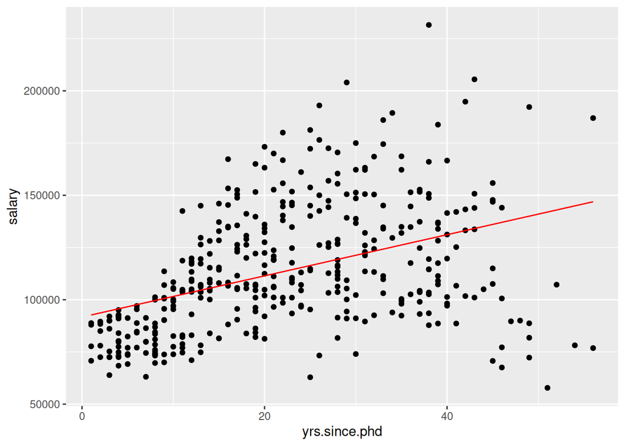

```r
Salaries %>% add_predictions(salary_mod) %>%
  ggplot() +
  geom_point(mapping=aes(x=yrs.since.phd, y=salary)) +
  geom_line(mapping=aes(x=yrs.since.phd, y=pred), color="red")
```

Based on this graph, it looks like the simple linear regression line may not capture everything happening in the data set. Large values of `yrs.since.phd` seem to actually have *lower* salaries.

One way to assess how well your model is doing is to graph its *residuals*. Remember that the residual is the difference between the *actual* response variable and the *predicted* value of the response variable. **If the model fits the data well, residuals should show no pattern and be vertically centered symmetrically around 0.**

Let’s use the `add_residuals` command to visualize residuals in our case. The new column added is called `resid`.

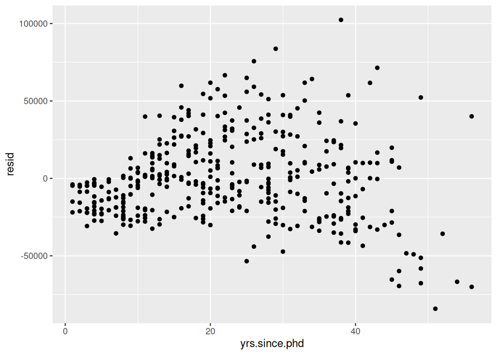

```r
Salaries %>% add_residuals(salary_mod) %>%
  ggplot() +
  geom_point(mapping = aes(x=yrs.since.phd, y=resid))
```

There is still a significant pattern in residuals! That means that our simple linear model is not a great fit to the data.

## Using `lm` with Categorical (Factor) Variables

The `lm` command can also be used with categorical predictor variables. For example, if I wanted to predict `salary` based on `rank`, I could do that:

```r
salary_mod2 <- lm(salary ~ rank, data=Salaries)
coef(salary_mod2)
```

```
##   (Intercept) rankAssocProf      rankProf
##      80775.99      13100.45      45996.12
```

These coefficients have the following meaning:

- Average base salary (salary for Assistant Professor) = 80775.99
- Average for Associate Professor = 80775.99 + 13100.45 = 93876.44
- Average for Full Professor = 80775.99 + 45996.12 = 126772.10

We could graph them by putting a big red dot on the predicted salary for each group.

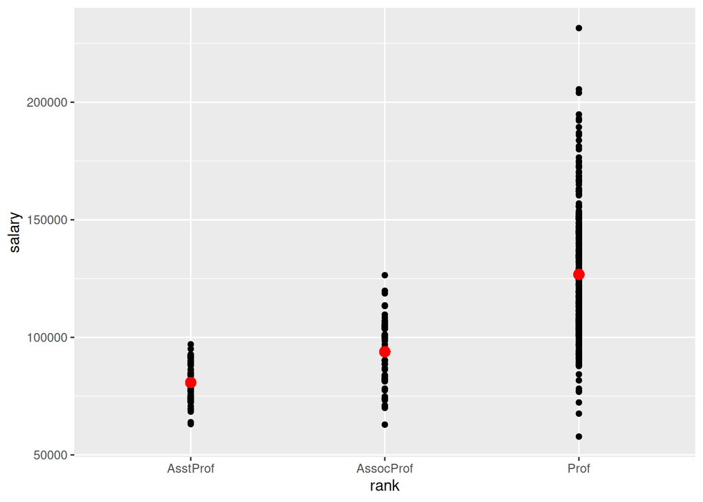

```r
Salaries %>% add_predictions(salary_mod2) %>%
  ggplot() +
  geom_point(mapping = aes(x=rank, y=salary)) +
  geom_point(mapping = aes(x=rank, y=pred), color="red", size=3)
```

### Question 4

Repeat the commands that created a linear model, showed coefficients, graphed predictions and graphed residuals, but this time to model `salary` as a function of `yrs.service`. Briefly explain whether the linear fit is a good fit in this example, referring to specific aspects of your output. **Answers and code below:**

```r
# Create linear model for salary as a function of yrs.service
salary_mod_service <- lm(salary ~ yrs.service, data=Salaries)
summary(salary_mod_service)
```

```
##
## Call:
## lm(formula = salary ~ yrs.service, data = Salaries)
##
## Residuals:
##    Min     1Q Median     3Q    Max
## -81933 -20511  -3776  16417 101947
##
## Coefficients:
##             Estimate Std. Error t value Pr(>|t|)
## (Intercept)  99974.7     2416.6   41.37  < 2e-16 ***
## yrs.service    779.6      110.4    7.06 7.53e-12 ***
## ---
## Signif. codes:  0 '***' 0.001 '**' 0.01 '*' 0.05 '.' 0.1 ' ' 1
##
## Residual standard error: 28580 on 395 degrees of freedom
## Multiple R-squared:  0.1121, Adjusted R-squared:  0.1098
## F-statistic: 49.85 on 1 and 395 DF,  p-value: 7.529e-12
```

```r
coef(salary_mod_service)
```

```
## (Intercept) yrs.service
##  99974.6529    779.5691
```

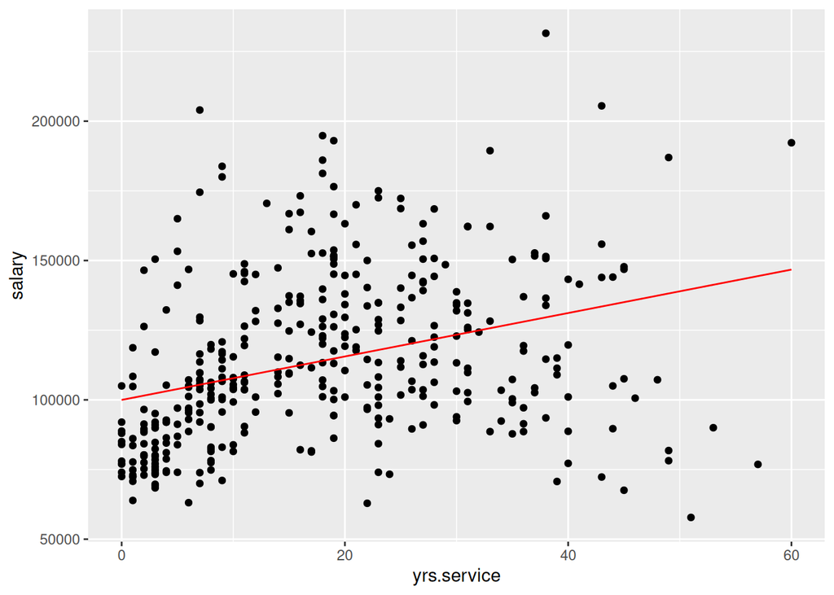

```r
# Graph predictions
Salaries %>% add_predictions(salary_mod_service) %>%
  ggplot() +
  geom_point(mapping=aes(x=yrs.service, y=salary)) +
  geom_line(mapping=aes(x=yrs.service, y=pred), color="red")
```

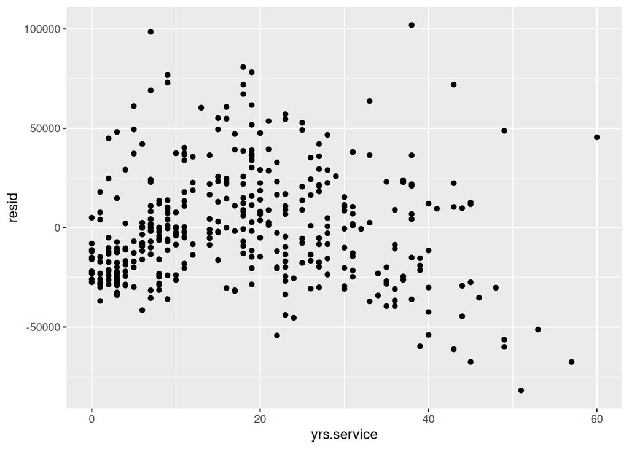

```r
# Graph residuals
Salaries %>% add_residuals(salary_mod_service) %>%
  ggplot() +
  geom_point(mapping = aes(x=yrs.service, y=resid))
```

The linear fit is **not good**. The residual plot shows a curved pattern instead of random dots around zero. The model over-predicts for people with few/many years of service but under-predicts for those in the middle range. We need a curved model, not a straight line.